# Statistical inference with the GSS data

## Setup

### Load packages

```r
library(ggplot2)
library(dplyr)
library(statsr)
library(gridExtra)
library(grid)
```

### Load data

```r
load("gss.Rdata")
```

## Part 1: Data

### Some information about Data.

Since 1972, the General Social Survey (GSS) has been collecting data on the contemporary American society in an attempt to follow the flow of social changes and identify/ understand emerging trends that come with these changes. To achieve this aim, the GSS contains a diverse range of information related to the general demographic as well as questions that are relevant to contemporary issues that span multiple categories, from behavioral, attitudinal, to social beliefs on various topics. These topics include civil liberties, social mobility, government functions, intergroup tolerance, physical and mental health, and income equality. Since the intention of the GSS is purely to gather data and provide them to any interested party, with minimal cost, the method conducted by the GSS is mainly random sampling, and thus serves the purpose of generalization. There is no social experiment conducted by the GSS and no random assignment is involved. Hence, there is no causal relation that can be established from GSS data.

For this document we are going to use data collected by surveying random US citizen. More specifically the data we are going to use are part of the the General Social Survey (GSS) conducted by the University of Chicago.

More precisely the data are composed of 57061 rows (or “cases”) and 115 columns (or “variables”). Each row represent the answers of a sampled citizen and every column represent the answers of all citizens to a specific question. A cell is obviously the answer of a citizen to a specific question. The full data will be identified by the R variable “GSS” during our analysis.

### What can we say about Causal Relationship?

Since the data was randomly selected but was not divided into treatment and control group therefore we can say that the inference is not at all causal but corelational if any.In simple words the data is purely observational therefore it would not be suitable for us to say that the inference is causal.

### What can we say about generalizability?

Since the data is the result of stratified sampling therefore we can easily say that the data can be generalizable to the entire U.S.A population.

Here we will be working with the most recent year in our dataset.

```r
max(gss$year)
```

```
## [1] 2012
```

Turns out 2012 is the most recent year therefore we would filter out all the other years and N/A values so to get the required data.We would rename it to the data2012

```r
# filtering observations from 2012 and N/A values.
data2012 <- gss %>%
  filter(year==2012 & !is.na(consci) & !is.na(degree))

data2012 %>% summarize(observations=n())
```

```
##   observations
## 1         1259
```

Total number of observations would be 1259.

## Part 2: Research question

Recently the fake news and fake science have dominated the internet. The freedom of sharing and creating any type of information, establishing “science” based on, for instance, a single experiment without any adequate control, is getting more and more frequent. A recent study has explored variables linking the beliefs on conspiracy theories and their capacity for critical thinking

Because this fact is of political, social and health concern, here we want to study the relations between the confidence in scientific community (consci) and the level of education (degree) in the US.

consci (confidence in scientific community): A GREAT DEAL, ONLY SOME, HARDLY ANY degree (highest degree): LT HIGH SCHOOL, HIGH SCHOOL, JUNIOR COLLEGE, BACHELOR, GRADUATE

The research question is defined as follows:

Do the majority of the Americans do have or don’t have full confidence in the scientific community?

Once we are going to work only with two variables, we reduce the number of columns of our data:

```r
data2012 <- data2012 %>%
  select(consci, degree)
```

## Part 3: Exploratory data analysis

We first analyze the counts of values in variables consci and degree:

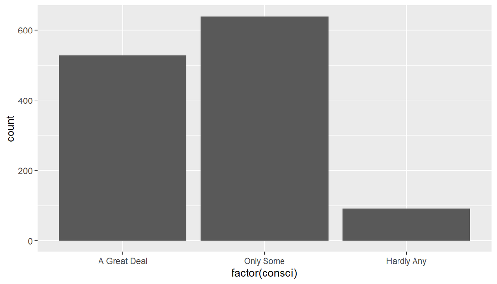

```r
ggplot(aes(x=factor(consci)), data=data2012) + geom_bar()
```

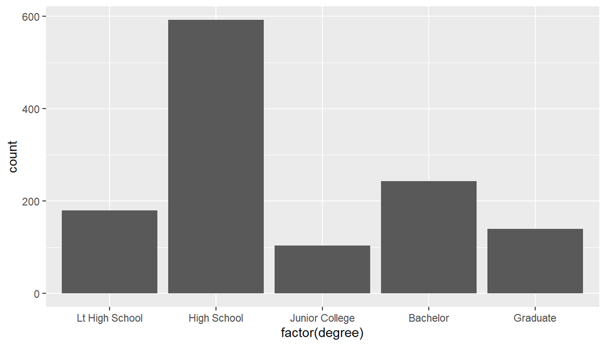

```r
ggplot(aes(x=factor(degree)), data=data2012) + geom_bar()
```

We would summarize whatever is in the dataset.

```r
summary(data2012)
```

```
##           consci               degree
##  A Great Deal:528   Lt High School:180
##  Only Some   :639   High School   :592
##  Hardly Any  : 92   Junior College:104
##                     Bachelor      :243
##                     Graduate      :140
```

## Part 4: Inference

This is what we would want to infer?

Can we consider that the majority of people do not trust entirely in the scientific community?

The hypothesis test is for checking if we can say that the majority of people do not give full confidence to the scientific community. Thus, we define our hypotheses as:

$H_0: p_{not\_great\_deal} = 0.5$

$H_A: p_{not\_great\_deal} > 0.5$

where **not_great_deal** represents the values “Only Some” and “Hardly Any”.

### Checking Conditions

```r
# Summary of proportion estimates
summ <- data2012 %>%
  summarize(success_p=sum(consci=="Only Some" | consci=="Hardly Any")/n(), failure_p=sum(consci=="A Great Deal")/n(), success_c=sum(consci=="Only Some" | consci=="Hardly Any"), failure_c=sum(consci=="A Great Deal"))

summ
```

```
##   success_p failure_p success_c failure_c
## 1 0.5806195 0.4193805       731       528
```

Thus, we met the conditions for the sampling distribution of $\hat p$ being nearly normal.

### Methods and Inference

Now, to compute the hypothesis test we set the null value to 0.5 and the alternative to “greater”:

```r
data2012 <- data2012 %>%
  mutate(science=ifelse(consci=="A Great Deal","A Great Deal", "Not A Great Deal" ))

inference(y = science, data = data2012, statistic = "proportion", type = "ht", method = "theoretical", conf_level = 0.95, alternative = "greater", null = 0.5, success = "Not A Great Deal", show_inf_plot = FALSE, show_eda_plot = FALSE)
```

[output not shown]